# Regularization

seokohj@hufs.ac.kr

# 벌점 회귀분석 Penalized regression

**Linear regression 모형**
$$y_n = \beta_0 + \beta_1 x_{n,1} + \cdots + \beta_d x_{n,d} + \epsilon_n,
\quad \epsilon_i \sim N(0,\sigma^2) \quad (n = 1,2,...,N)$$
또는
$$\boldsymbol{y} = \boldsymbol{X}{\boldsymbol\beta} +
{\boldsymbol\epsilon},\quad {\boldsymbol\epsilon}\sim N\left({\mathbf
0}_N, \sigma^2 \boldsymbol{I}_N\right)$$

- ${\boldsymbol\beta}$의 최소제곱추정량
  $$\hat{\boldsymbol\beta} = (\boldsymbol{X}^\top \boldsymbol{X})^{-1}
  \boldsymbol{X}^\top \boldsymbol{y}$$
  - 제곱오차 $\|\boldsymbol{y} - \boldsymbol{X}\boldsymbol\beta\|_2^2$ 를 최소로 하는 방법
  - 이론적으로 가장 우수한 방법임: BLUE (best linear unbiased estimator) 성질

  **[참고]** 벡터의 ${\cal L}_q$-노옴(norm): $\,\,\boldsymbol{x} = (x_1, x_2, ..., x_N)^\top \in \mathbb{R}^N$일 때, $\|\boldsymbol{x}\|_q = \left\{\sum_{n=1}^N \left|x_n\right|^q\right\}^{1/q}$.
  $$\begin{eqnarray*}
  & & (q = 1) \quad \|\boldsymbol{x}\|_1 = \sum_{n=1}^N
  \left|x_n\right|\\
  & & (q = 2) \quad \|\boldsymbol{x}\|_2 = \left\{\sum_{n=1}^N
  x_n^2\right\}^{1/2} \equiv \left(\boldsymbol{x}^\top
  \boldsymbol{x}\right)^{1/2}
  \end{eqnarray*}$$
- **Issue 1** (Large $d$, small $N$)
  - $X^\top X$의 역행렬이 존재하지 않기 때문에 최소제곱법으로 학습 불가능
- **Issue 2** (Bias-Variance trade-off)
  - 평균제곱오차의 분해: ${\sf MSE} = {\sf Bias}^2 + {\sf Variance}$
    $$\begin{eqnarray*}
    \because \quad{\sf MSE}
    &=& {\sf E}\left[\left(\hat{\boldsymbol\theta} -
    \boldsymbol\theta\right)^2\right]
    = {\sf E}\left[\left\{\hat{\boldsymbol\theta} - {\sf
    E}(\hat{\boldsymbol\theta}) + {\sf E}(\hat{\boldsymbol\theta}) -
    \boldsymbol\theta\right\}^2\right] \\
    &=& {\sf E}\left[\left\{\hat{\boldsymbol\theta} - {\sf
    E}(\hat{\boldsymbol\theta})\right\}^2\right] + \left\{{\sf
    E}(\hat{\boldsymbol\theta}) -\boldsymbol\theta\right\}^2 = {\sf
    Variance} + {\sf Bias}^2
    \end{eqnarray*}$$
  - Bias를 줄이려면 모형을 복잡하게 만들면 됨. 대신 Variance가 증가하게 됨.
  - Variance를 줄이려면 모형이 단순해야 함. 대신 Bias가 증가하게 됨
  - 비편향성(unbiasedness)을 무조건 고수해야 하는가?

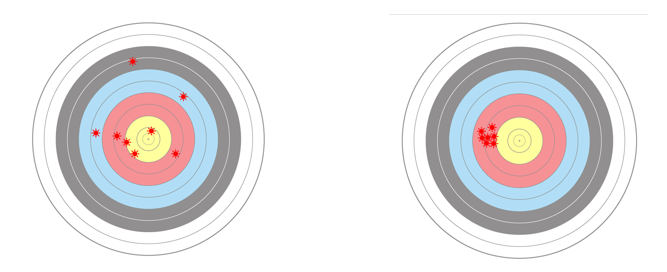

## Ridge regression

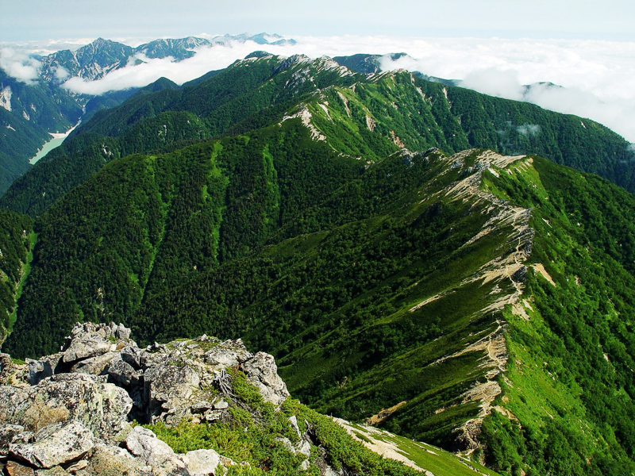

$$\hat{\boldsymbol{\beta}}_{\sf ridge} = (\boldsymbol{X}^\top
\boldsymbol{X} + \lambda
\boldsymbol{I})^{-1}\boldsymbol{X}^\top\boldsymbol{y}$$

- 학습 과정에서 추정치를 ($\boldsymbol{0}$ 방향으로) shrink시켜, 약간의 bias를 감내하고 분산을 줄이는 아이디어
- 최소제곱법에서 사용하는 제곱오차에 모형의 복잡도에 대해 벌점을 추가 부여한 손실함수를 최소로 하는 solution을 찾음.
  $${\cal L}(\boldsymbol\beta) = \mbox{(Goodness of fit)} + \mbox{(Penalty)}
  = \| \boldsymbol{y} - \boldsymbol{X}{\boldsymbol{\beta}}\|_2^2 +
  \lambda \|{\boldsymbol{\beta}}\|_2^2$$
- 이 손실함수는 (strictly) convex in $\boldsymbol\beta$. 따라서 최적해가 유일하게 존재.
  $$\hat{\boldsymbol{\beta}}_{\sf ridge}
  =\arg\!\min_{\boldsymbol{\beta}}\left\{ \| \boldsymbol{y} -
  \boldsymbol{X}{\boldsymbol{\beta}}\|_2^2 + \lambda
  \|{\boldsymbol{\beta}}\|_2^2 \right\}$$
- 위 최적화 문제는 다음과 동치:
  $$\text{To find } \boldsymbol{\beta} \text{ minimizing } \| \boldsymbol{y}
  - \boldsymbol{X}{\boldsymbol{\beta}}\|_2^2 \text{ subject to
  }\|{\boldsymbol{\beta}}\|_2 \le R \text{ for some }R>0$$

## LASSO (least absolute shrinkage and selection operator)

- 위의 ridge 회귀의 벌점 부분을 절대값 노옴(${\mathcal L}_1$)으로 대체
  $$\hat{\boldsymbol{\beta}}_{\sf lasso}
  =\arg\!\min_{\boldsymbol{\beta}}\left\{ \| \boldsymbol{y} -
  \boldsymbol{X}{\boldsymbol{\beta}}\|_2^2 + \lambda
  \|{\boldsymbol{\beta}}\|_1 \right\}$$
- 이 손실함수 역시 $\boldsymbol\beta$에 대해 convex
- 이 최적화 문제는 다음 문제와 동치:
  $$\text{To find }\boldsymbol{\beta} \text{ minimizing }\| \boldsymbol{y} -
  \boldsymbol{X}{\boldsymbol{\beta}}\|_2^2 \text{ subject to
  }\|{\boldsymbol{\beta}}\|_1 \le R \text{ for some }R>0$$

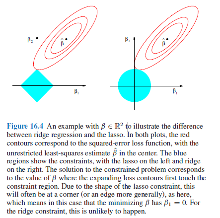

## $\lambda$의 선택

**교차확인법(cross-validation)**

- Leave-one-out
  $$\textsf{CV}(\lambda) = \frac{1}{N}\sum_{i=1}^N\sum_{n\neq i}(y_n -
  \boldsymbol{x}_n^\top\boldsymbol\beta_{(-i)})^2$$

**(c.f.)** 베이지안 방법

## 예제 데이터: 모의실험 데이터

- Variables: $(y, x_1, x_2, ..., x_{100})$
- DGP:
  - $x_j\sim {\sf Uniform}(0, 1)$, $j=1,2,...,100$
  - $y = 10 + 1\times x_1 + 2\times x_2 + ... + 5\times x_5 + \epsilon$, $\epsilon\sim N(0, 0.25^2)$ (즉, $x_6, x_7, ...x_{100}$은 $y$값과 무관)
- 표본 크기 $n = 50$. 데이터 차원에 비해 매우 작은 크기임.

```r
library(glmnet)
set.seed(0)
n <- 50
p <- 100

sigma <- 0.25
beta <- c(1:5, rep(0, p - 5))

x <- cbind(matrix(runif(n*p), n, p))
y <- 10 + as.vector(x%*%beta) + sigma*rnorm(n)
```

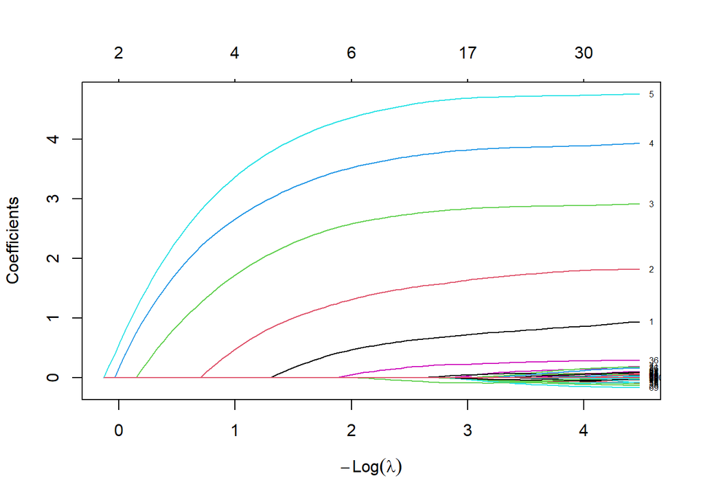

```r
fit <- glmnet(x, y)
plot(fit, xvar = "lambda", label = TRUE)
```

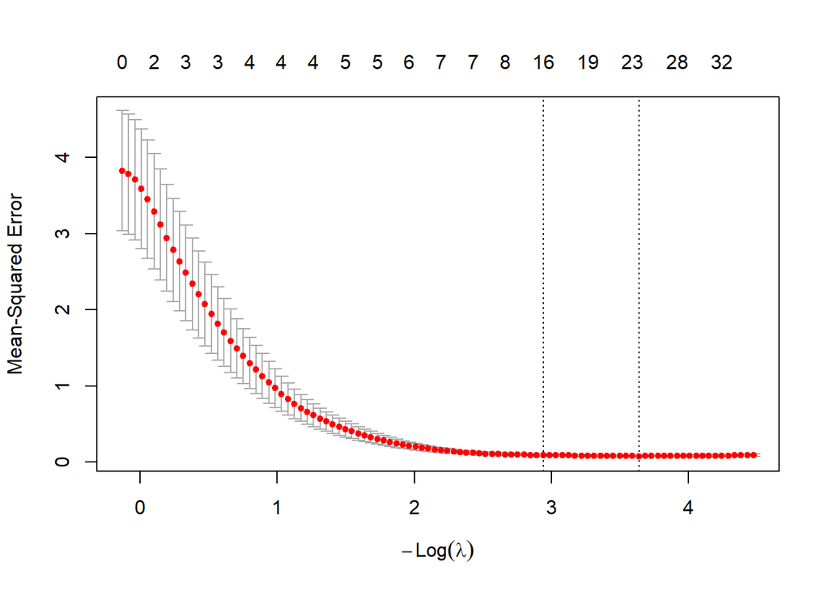

```r
cvfit <- cv.glmnet(x, y)
plot(cvfit)
```

```r
print(s <- cvfit$lambda.min)
```

```
## [1] 0.026306
```

```r
print(log(s))
```

```
## [1] -3.637958
```

```r
beta.hat <- coef(cvfit, s = "lambda.min")
print(round(drop(beta.hat), 4))
```

```
## (Intercept)          V1          V2          V3          V4          V5
##     10.4331      0.8143      1.7525      2.8741      3.8671      4.7221
##          V6          V7          V8          V9         V10         V11
##      0.0000      0.1177      0.0000      0.0030     -0.0582      0.0000
##         V12         V13         V14         V15         V16         V17
##      0.0000      0.0000      0.0000     -0.0716      0.0000     -0.0927
##         V18         V19         V20         V21         V22         V23
##      0.0000      0.0000      0.0000      0.0000      0.0000      0.0000
##         V24         V25         V26         V27         V28         V29
##      0.0000      0.0000     -0.0214      0.0000      0.0000      0.0000
##         V30         V31         V32         V33         V34         V35
##      0.0000      0.0950      0.0000      0.0000      0.0000      0.0000
##         V36         V37         V38         V39         V40         V41
##      0.2646      0.0000      0.0000      0.0000      0.0000      0.0000
##         V42         V43         V44         V45         V46         V47
##      0.0000      0.0000      0.0000      0.0000      0.0000      0.0000
##         V48         V49         V50         V51         V52         V53
##      0.0000      0.0000      0.0000      0.0000      0.0000      0.0000
##         V54         V55         V56         V57         V58         V59
##      0.0000     -0.0937      0.0000      0.0000      0.0000      0.0004
##         V60         V61         V62         V63         V64         V65
##      0.0000      0.0607      0.0000      0.0000      0.0000      0.0560
##         V66         V67         V68         V69         V70         V71
##      0.0506      0.0000      0.0000     -0.1250      0.0000      0.0000
##         V72         V73         V74         V75         V76         V77
##      0.0000     -0.0500      0.0000      0.0000      0.0000      0.0000
##         V78         V79         V80         V81         V82         V83
##      0.0000      0.0000      0.0000      0.0000      0.0000      0.0000
##         V84         V85         V86         V87         V88         V89
##     -0.0568      0.0000      0.0661     -0.0083      0.0000      0.0000
##         V90         V91         V92         V93         V94         V95
##      0.0000      0.0000      0.0153      0.0000      0.0000      0.0296
##         V96         V97         V98         V99        V100
##      0.0000      0.0000      0.0000      0.0000      0.0000
```

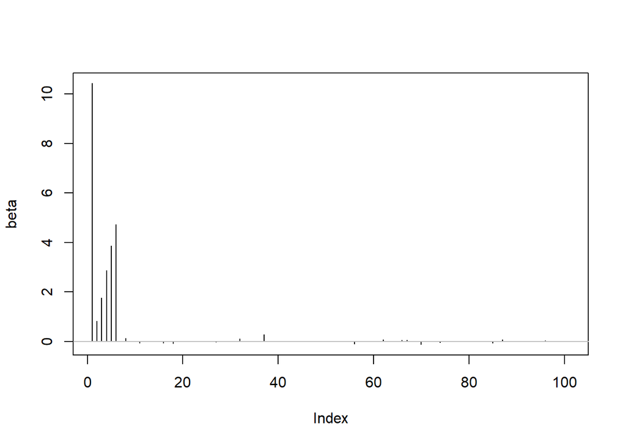

```r
plot(drop(beta.hat), type = "h", ylab = "beta")
abline(h = 0, col = "gray")
```

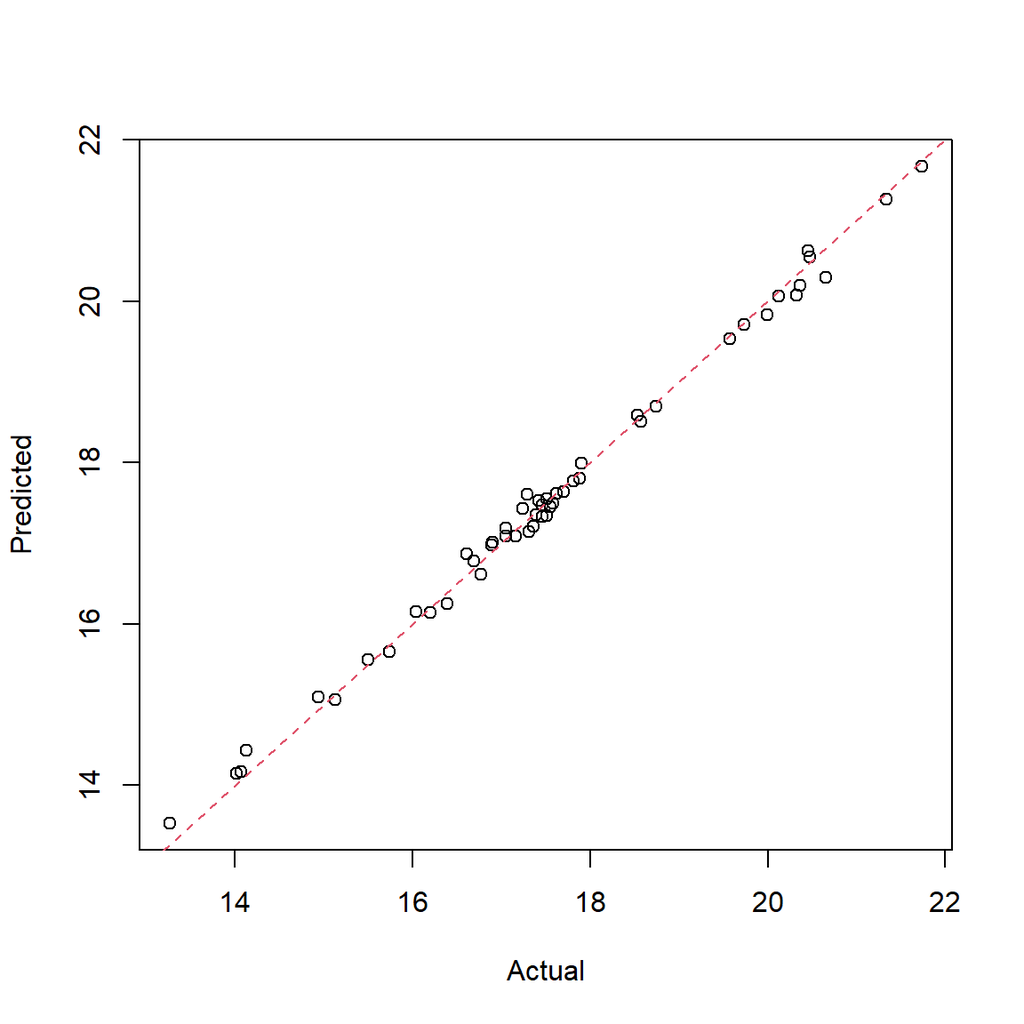

```r
pred.lasso <- predict(fit, newx = x, s = s)
plot(y, pred.lasso, xlab = "Actual", ylab = "Predicted")
abline(0, 1, col = 2, lty = 2)
```

## Elastic-net

- 벌점 부분에 ${\mathcal L}_1$-norm과 ${\mathcal L}_2$-norm을 함께 사용
  $$\frac{1 - \alpha}{2} \|\boldsymbol\beta \|_2^2 + \alpha
  \|\boldsymbol\beta\|_1$$
- $\alpha = 0$이면 ridge regression, $\alpha = 1$이면 lasso regression에 해당

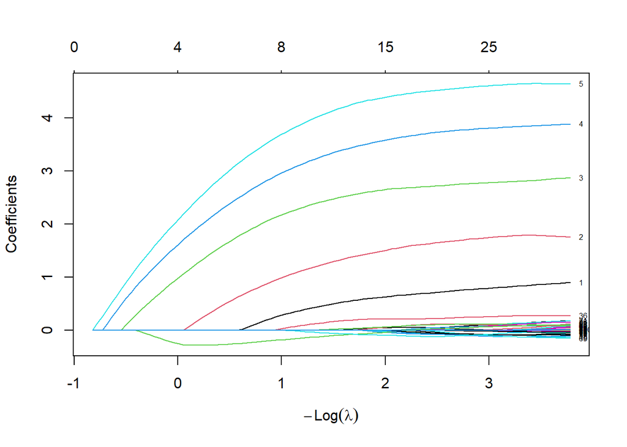

```r
fit <- glmnet(x, y, alpha = .5)
plot(fit, xvar = "lambda", label = TRUE)
```

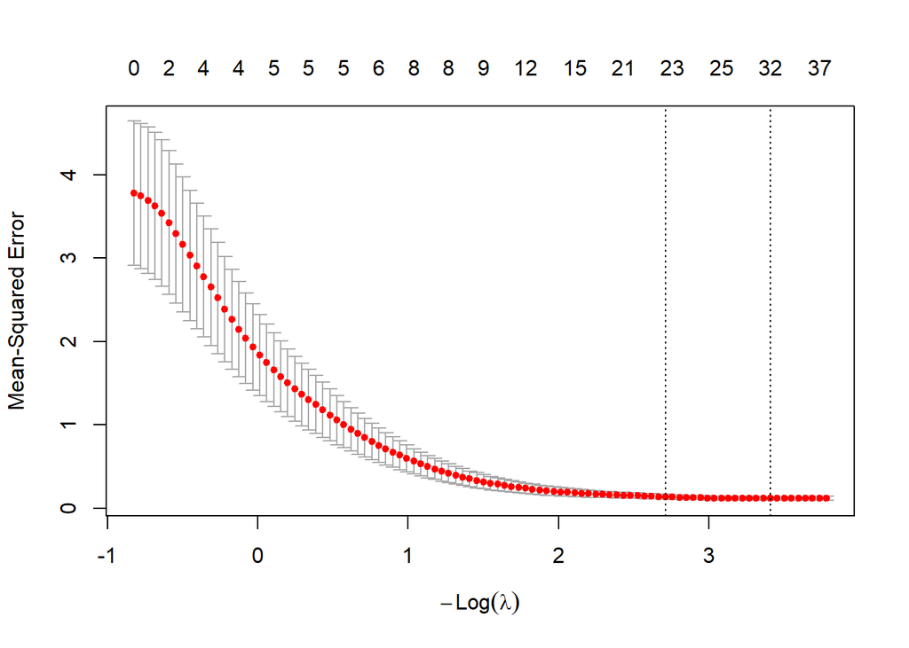

```r
cvfit <- cv.glmnet(x, y, alpha = .5)
plot(cvfit)
```

```r
print(s <- cvfit$lambda.min)
```

```
## [1] 0.03304186
```

```r
print(log(s))
```

```
## [1] -3.40998
```

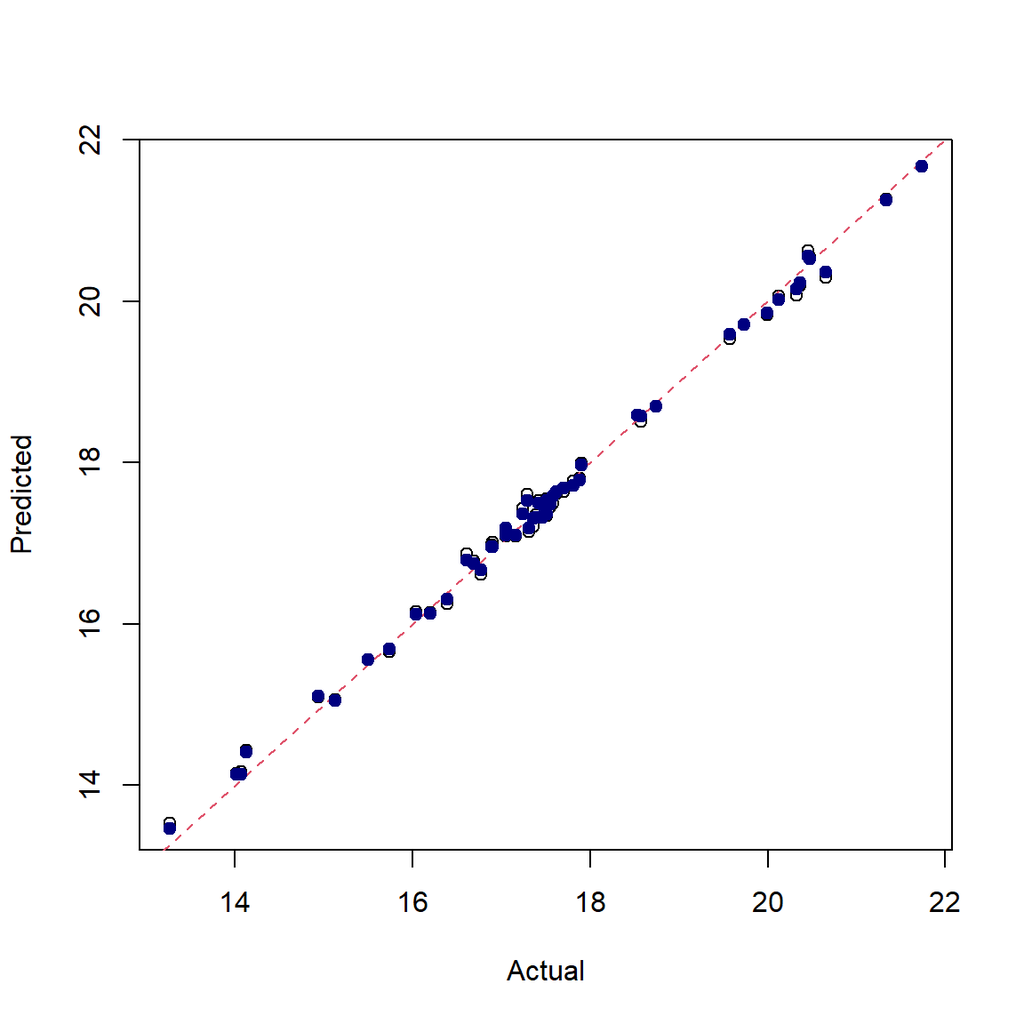

```r
plot(y, pred.lasso, xlab = "Actual", ylab = "Predicted")
abline(0, 1, col = 2, lty = 2)
points(y, predict(fit, newx = x, s = s), col = "navy", pch = 19)
```

```r
round(sqrt(mean((y - pred.lasso)^2)), 4)  # RMSE: LASSO
```

```
## [1] 0.1402
```

```r
round(sqrt(mean((y - predict(fit, newx = x, s = s))^2)), 4) # RMSE: Elastic Net
```

```
## [1] 0.1135
```

## 일반화선형회귀로 확장

- GLM 세팅에도 활용 가능
  - 선형회귀모형과 달리 제곱오차가 아닌 가능도함수값을 기준으로 모수 추정
  - Negative log-likelihood + penalty 를 최소로 하는 회귀계수를 찾음

## 예제: 로지스틱 회귀

```r
data(BinomialExample)
str(BinomialExample)
```

```
## List of 2
##  $ x: num [1:100, 1:30] -0.619 1.094 -0.357 -2.469 0.567 ...
##  $ y: int [1:100] 0 1 1 0 1 0 0 0 1 1 ...
```

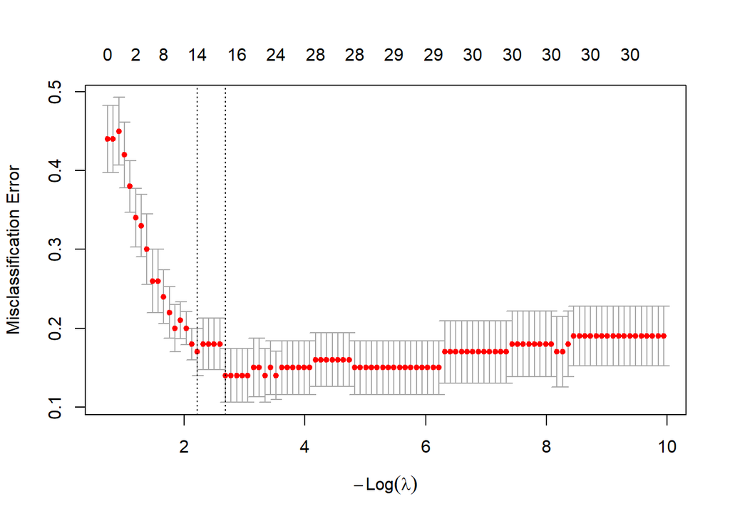

```r
# Check the Environment tab

fit <- glmnet(BinomialExample$x, BinomialExample$y, family = "binomial", alpha = .5) # Elastic Net

cvfit <- cv.glmnet(BinomialExample$x, BinomialExample$y, alpha = .5, family = "binomial", type.measure = "class")
plot(cvfit)
```

```r
print(s <- cvfit$lambda.min)
```

```
## [1] 0.06817377
```

```r
log(s)
```

```
## [1] -2.685695
```

```r
pred <- predict(fit, newx = BinomialExample$x, type = "class", s = s)
table(BinomialExample$y, pred)
```

```
##    pred
##      0  1
##   0 40  4
##   1  1 55
```

> 방문해서 살펴보세요. https://glmnet.stanford.edu/articles/glmnet.html